```r
kruskal.test( 검색포털_usagetime ~ cluster, data = old)
```

```
##
##  Kruskal-Wallis rank sum test
##
## data:  검색포털_usagetime by cluster
## Kruskal-Wallis chi-squared = 7.4526, df = 2, p-value = 0.02408
```

```r
kruskal.test( 멤버십.할인쿠폰_usagetime ~ cluster, data = old)
```

```
##
##  Kruskal-Wallis rank sum test
##
## data:  멤버십.할인쿠폰_usagetime by cluster
## Kruskal-Wallis chi-squared = 9.8798, df = 2, p-value = 0.007155
```

```r
kruskal.test( 동영상.스트리밍_usagetime ~ cluster, data = old)
```

```
##
##  Kruskal-Wallis rank sum test
##
## data:  동영상.스트리밍_usagetime by cluster
## Kruskal-Wallis chi-squared = 9.916, df = 2, p-value = 0.007027
```

```r
kruskal.test( 게임_usagetime ~ cluster, data = old)
```

```
##
##  Kruskal-Wallis rank sum test
##
## data:  게임_usagetime by cluster
## Kruskal-Wallis chi-squared = 11.032, df = 2, p-value = 0.004022
```

```r
#돈버는 리워드 빼고는 집단간 차이 있음


old %>% select(Y0001,cluster) %>% group_by(cluster) %>% summarise_all(funs(round(mean(.))))
```

```
## # A tibble: 3 x 2
##   cluster Y0001
##   <fct>   <dbl>
## 1 0           3
## 2 1           3
## 3 2           4
```

```r
#old는 평균적으로 핵가족(3,4인) 형태

old %>% select(cluster,Y0001) %>%table()
```

```
##        Y0001
## cluster   1   2   3   4   5
##       0  44 129 258 382 113
##       1  25  72 101 179  48
##       2   0   7  15  39  15
```

```r
round(prop.table(table(old$cluster,old$Y0001),1)*100)
```

```
##
##      1  2  3  4  5
##   0  5 14 28 41 12
##   1  6 17 24 42 11
##   2  0  9 20 51 20
```

```r
family_prop<-as.matrix(round(prop.table(table(old$cluster,old$Y0001),1)*100))
kruskal.test( Y0001 ~ cluster, data = old)
```

```
##
##  Kruskal-Wallis rank sum test
##
## data:  Y0001 by cluster
## Kruskal-Wallis chi-squared = 11.783, df = 2, p-value = 0.002763
```

```r
#군집간 가족원수 차이 있음

with_child<-apply(family_prop[,3:5],1,sum)
no_child<-100-with_child
family_size<-as.data.frame(t(rbind(no_child,with_child)))
family_size
```

```
##   no_child with_child
## 0       19         81
## 1       23         77
## 2        9         91
```

```r
#heavyuser의 경우 3인가구 이상이 90%이상-> 자녀와 같이 살아서 간편결제에 더 쉽게 접할 수 있어보임


old %>% select(Y0008,cluster) %>% group_by(cluster) %>% summarise_all(funs(round(mean(.))))
```

```
## # A tibble: 3 x 2
##   cluster Y0008
##   <fct>   <dbl>
## 1 0           4
## 2 1           4
## 3 2           4
```

```r
#가구 평균연간소득 5천 ~ 7천(소득 발설하기 싫은 심리 반영한 것일 수 있음)

round(prop.table(table(old$cluster,old$Y0009),1)*100)
```

```
##
##      1  2  3  4  5 997
##   0 12 70  2  2 12   2
##   1 13 67  2  0 16   2
##   2  8 82  1  0  9   0
```

```r
fisher.test(table(old$cluster,old$Y0009), simulate.p.value=TRUE)
```

```
##
##  Fisher's Exact Test for Count Data with simulated p-value (based
##  on 2000 replicates)
##
## data:  table(old$cluster, old$Y0009)
## p-value = 0.2794
## alternative hypothesis: two.sided
```

```r
#군집과 현재 거주 중인 주택의 형태는 연관성이 없다.


round(prop.table(table(old$cluster,old$Y0010),1)*100)
```

```
##
##      1  2  3 997
##   0 74 16  9   2
##   1 68 16 13   3
##   2 87 11  1   1
```

```r
fisher.test(table(old$cluster,old$Y0010), simulate.p.value=TRUE)
```

```
##
##  Fisher's Exact Test for Count Data with simulated p-value (based
##  on 2000 replicates)
##
## data:  table(old$cluster, old$Y0010)
## p-value = 0.003998
## alternative hypothesis: two.sided
```

```r
#1 군집에 비해 2군집에서 월세는 낮고 자가가 높은 것을 보아 heavyuser의 재산이 더 많아 보인다. -> 재산이 많을수록 간편결제 이용 올라감
#군집과 현재 거주 중인 주택의 보유 형태는 연관성이 있다.


round(prop.table(table(old$cluster,old$H0008),1)*100)
```

```
##
##      1  2  3  4  5
##   0 65 10 19  4  2
##   1 64 10 19  5  2
##   2 57  9 24  7  4
```

```r
round(prop.table(table(old$cluster,old$H0009),1)*100)
```

```
##
##      1  2  3  4  5
##   0 60 12 20  5  3
##   1 66 10 17  4  2
##   2 49 16 20  7  9
```

```r
#평균적으로 비행기 탑승횟수 0회: 60%
#0,1군집은 지난 1년간 국내선/국제선 탑승회수 비슷
#2군집은 지난 1년간 국내선/국제선 탑승회수 더 많음 -> 여가를 즐기거나 여유있음
kruskal.test( H0008 ~ cluster, data = old)
```

```
##
##  Kruskal-Wallis rank sum test
##
## data:  H0008 by cluster
## Kruskal-Wallis chi-squared = 2.8355, df = 2, p-value = 0.2423
```

```r
kruskal.test( H0009 ~ cluster, data = old)
```

```
##
##  Kruskal-Wallis rank sum test
##
## data:  H0009 by cluster
## Kruskal-Wallis chi-squared = 10.615, df = 2, p-value = 0.004954
```

```r
#군집간 국내선 탑승횟수는 차이 없음, 국제선 탑승회수는 차이 있음


old %>% select(H0010,cluster) %>% group_by(cluster) %>% summarise_all(funs(round(mean(.),2)))
```

```
## # A tibble: 3 x 2
##   cluster H0010
##   <fct>   <dbl>
## 1 0        0.55
## 2 1        0.59
## 3 2        0.67
```

```r
#통근자 비율 0<1<2 군집
#kruskal.test( H0010 ~ cluster, data = old)
chisq.test(table(old$cluster,old$H0010))
```

```
##
##  Pearson's Chi-squared test
##
## data:  table(old$cluster, old$H0010)
## X-squared = 4.8294, df = 2, p-value = 0.08939
```

```r
#하지만 검정 결과 통근여부와 군집은 연관성이 없다.


old %>% select(H0022,cluster) %>% group_by(cluster) %>% summarise_all(funs(round(mean(.),2)))
```

```
## # A tibble: 3 x 2
##   cluster H0022
##   <fct>   <dbl>
## 1 0        0.74
## 2 1        0.71
## 3 2        0.84
```

```r
#"현재 자가용 자가 운전비율" 2군집이 가장 높음
chisq.test(table(old$cluster,old$H0022))
```

```
##
##  Pearson's Chi-squared test
##
## data:  table(old$cluster, old$H0022)
## X-squared = 6.3258, df = 2, p-value = 0.0423
```

```r
#현재 자가용 자가 운전 여부와 군집은 상관있음

old %>% select(I0025,I0026,I0028,cluster) %>% group_by(cluster) %>% summarise_all(funs(round(mean(.),2)))
```

```
## # A tibble: 3 x 4
##   cluster I0025 I0026 I0028
##   <fct>   <dbl> <dbl> <dbl>
## 1 0        0.65  0.48  0.08
## 2 1        0.65  0.68  0.1
## 3 2        0.64  0.7   0.26
```

```r
chisq.test(table(old$cluster,old$I0025))
```

```
##
##  Pearson's Chi-squared test
##
## data:  table(old$cluster, old$I0025)
## X-squared = 0.018035, df = 2, p-value = 0.991
```

```r
chisq.test(table(old$cluster,old$I0026))
```

```
##
##  Pearson's Chi-squared test
##
## data:  table(old$cluster, old$I0026)
## X-squared = 49.502, df = 2, p-value = 1.781e-11
```

```r
chisq.test(table(old$cluster,old$I0028))
```

```
##
##  Pearson's Chi-squared test
##
## data:  table(old$cluster, old$I0028)
## X-squared = 26.819, df = 2, p-value = 1.501e-06
```

```r
# 모바일쇼핑/해외직구 비율: 0<1<2군집  (인터넷쇼핑은 차이없음)
# 군집과 지난 3개월 간 인터넷 쇼핑 이용 여부는 연관없음
# 군집과 지난 3개월 간 모바일쇼핑/해외직구 이용 여부는 연관있음


round(prop.table(table(old$cluster,old$J0001),1)*100)
```

```
##
##      1  2  3  4  5
##   0  6 22 42 16 14
##   1  3 24 37 18 17
##   2  5 22 43 11 18
```

```r
round(prop.table(table(old$cluster,old$J0003),1)*100)
```

```
##
##      1  2  3  4  5
##   0 15 25 41 12  6
##   1 14 23 41 13 10
##   2 12 29 47  7  5
```

```r
kruskal.test( J0001 ~ cluster, data = old)
```

```
##
##  Kruskal-Wallis rank sum test
##
## data:  J0001 by cluster
## Kruskal-Wallis chi-squared = 2.0574, df = 2, p-value = 0.3575
```

```r
kruskal.test( J0003 ~ cluster, data = old)
```

```
##
##  Kruskal-Wallis rank sum test
##
## data:  J0003 by cluster
## Kruskal-Wallis chi-squared = 3.7759, df = 2, p-value = 0.1514
```

```r
#인터넷 하루이용시간 군집간 전반적으로 비슷, 군집간 차이 없음

round(prop.table(table(old$cluster,old$J0002),1)*100)
```

```
##
##      1  2  3  4  5
##   0  2 21 42 20 16
##   1  1 17 38 24 20
##   2  0 18 37 25 20
```

```r
round(prop.table(table(old$cluster,old$J0004),1)*100)
```

```
##
##      1  2  3  4  5
##   0  1 23 42 20 13
##   1  1 19 33 28 19
##   2  1 20 32 22 25
```

```r
kruskal.test( J0002 ~ cluster, data = old)
```

```
##
##  Kruskal-Wallis rank sum test
##
## data:  J0002 by cluster
## Kruskal-Wallis chi-squared = 10.781, df = 2, p-value = 0.004561
```

```r
kruskal.test( J0004 ~ cluster, data = old)
```

```
##
##  Kruskal-Wallis rank sum test
##
## data:  J0004 by cluster
## Kruskal-Wallis chi-squared = 18.407, df = 2, p-value = 0.0001007
```

```r
#스마트폰 평일/주말 기준 하루이용시간 0<1,2군집, 군집간 차이 있음

old %>% select(J0078,cluster) %>% group_by(cluster) %>% summarise_all(funs((mean(.))))
```

```
## # A tibble: 3 x 2
##   cluster J0078
##   <fct>   <dbl>
## 1 0       0.997
## 2 1       1
## 3 2       1
```

```r
#스마트폰 보유 여부 (거의 1)

old %>% select(J0079,J0080,J0081,cluster) %>% group_by(cluster) %>% summarise_all(funs(round(mean(.),2)))
```

```
## # A tibble: 3 x 4
##   cluster J0079 J0080 J0081
##   <fct>   <dbl> <dbl> <dbl>
## 1 0        0.76  0.2      0
## 2 1        0.82  0.16     0
## 3 2        0.95  0.04     0
```

```r
##**상위 군집일수록 삼성폰 가진 비율 큼 -> 기기의 중요성
chisq.test(table(old$cluster,old$J0079))
```

```
##
##  Pearson's Chi-squared test
##
## data:  table(old$cluster, old$J0079)
## X-squared = 17.933, df = 2, p-value = 0.0001276
```

```r
#디지털기기) 현재 삼성스마트폰 보유 여부와 군집은 연관 있음
chisq.test(table(old$cluster,old$J0080))
```

```
##
##  Pearson's Chi-squared test
##
## data:  table(old$cluster, old$J0080)
## X-squared = 13.686, df = 2, p-value = 0.001067
```

```r
#디지털기기) 현재 LG폰 보유 여부와 군집은 연관 있음


round(prop.table(table(old$cluster,old$L0031),1)*100)
```

```
##
##      1  2  3  4  5  6  7  9 10 11 12 997 998
##   0 48  8  5 13  1  0 20  2  0  0  0   0   3
##   1 38 10  5 16  1  1 19  5  0  0  0   0   2
##   2 41  5  3 12  0  0 33  3  0  0  0   0   4
```

```r
fisher.test(table(old$cluster,old$L0031), simulate.p.value=TRUE)
```

```
##
##  Fisher's Exact Test for Count Data with simulated p-value (based
##  on 2000 replicates)
##
## data:  table(old$cluster, old$L0031)
## p-value = 0.007996
## alternative hypothesis: two.sided
```

```r
# TV컨텐츠) 주시청 장르(1순위)와 군집은 연관있음
# 2군집은 드라마, 1군집은 스포츠, 예능, 0군집은 뉴스에서 다른 군집 대비 큰 비율을 보임 -> 간편결제 사용자가 미사용자에 비해 여흥거리나 트렌드에 더 높은 관심이 있을 수 있음


finanace<-old %>% select(paste0('M00',17:27),cluster) %>% group_by(cluster) %>% summarise_all(funs(round(mean(.),2)))
#View(finanace)
chisq.test(table(old$cluster,old$M0017))
```

```
##
##  Pearson's Chi-squared test
##
## data:  table(old$cluster, old$M0017)
## X-squared = 3.0045, df = 2, p-value = 0.2226
```

```r
chisq.test(table(old$cluster,old$M0020))
```

```
##
##  Pearson's Chi-squared test
##
## data:  table(old$cluster, old$M0020)
## X-squared = 0.58161, df = 2, p-value = 0.7477
```

```r
chisq.test(table(old$cluster,old$M0022))
```

```
##
##  Pearson's Chi-squared test
##
## data:  table(old$cluster, old$M0022)
## X-squared = 2.6197, df = 2, p-value = 0.2699
```

```r
fisher.test(table(old$cluster,old$M0024),simulate.p.value=TRUE)
```

```
##
##  Fisher's Exact Test for Count Data with simulated p-value (based
##  on 2000 replicates)
##
## data:  table(old$cluster, old$M0024)
## p-value = 0.1384
## alternative hypothesis: two.sided
```

```r
chisq.test(table(old$cluster,old$M0025))
```

```
##
##  Pearson's Chi-squared test
##
## data:  table(old$cluster, old$M0025)
## X-squared = 1.0246, df = 2, p-value = 0.5991
```

```r
chisq.test(table(old$cluster,old$M0026)) #연관있음
```

```
##
##  Pearson's Chi-squared test
##
## data:  table(old$cluster, old$M0026)
## X-squared = 10.344, df = 2, p-value = 0.005674
```

```r
#지난 1년간 보험가입, 예적금가입, 펀드가입 등의 전반적인 금융생활은 군집과 연관 없음
#금융활동) 지난 1년 간 신규 신용 대출 경험 여부만 연관있고 1>2>0 순
```

```r
#[PPDB] X 추가 분석
#old2<-read.csv("C:/Users/JunghaYun/Desktop/최종데이터/payments_ppdb_app_g_x_category_code_aggregated_cp949.csv", stringsAsFactors = FALSE)

#old2<-old2 %>% filter(age>=50)
#old2 %>% summarise(n())

#old<-read.csv("C:/Users/JunghaYun/desaip/deguri/analysis/analysis_by_Yun/5060_3cluster.csv",stringsAsFactors = FALSE)
#old %>% summarise(n())

#old3<-full_join(old,old2, by="panel_id")

# old3<-old
# old3$cluster<-as.factor(old3$cluster)
# table(old3$cluster)

#나이(설문조사의 나이와 실제나이가 차이가 남->실제나이로 분석)
#old %>% filter(X0003>=9) %>% summarise(n())
#old %>% filter(age>=50) %>% summarise(n())
#hist(old3$age.x)
old<-old %>% mutate(age_class=ifelse(age<55,'50대초',ifelse(age<60,'50대후',ifelse(age<65,'60대초',ifelse(age<70,'60대후','70대이상')))))

#전체패널 나이
table(old$age_class)
```

```
##
##   50대초   50대후   60대초   60대후 70대이상
##      793      374      200       48       12
```

```r
#군집별 나이
table(old$cluster,old$age_class)
```

```
##
##     50대초 50대후 60대초 60대후 70대이상
##   0    492    251    135     39        9
##   1    251    106     58      7        3
##   2     50     17      7      2        0
```

```r
round(prop.table(table(old$cluster,old$age_class),1)*100)
```

```
##
##     50대초 50대후 60대초 60대후 70대이상
##   0     53     27     15      4        1
##   1     59     25     14      2        1
##   2     66     22      9      3        0
```

```r
#결혼상태
chisq.test(table(old$cluster,old$X0007))
```

```
##
##  Pearson's Chi-squared test
##
## data:  table(old$cluster, old$X0007)
## X-squared = 10.879, df = 4, p-value = 0.02795
```

```r
#결혼상태와 군집은 연관이 있다.
round(prop.table(table(old$cluster,old$X0007),1)*100)
```

```
##
##      1  2  3
##   0  7 86  7
##   1  6 84 10
##   2  5 93  1
```

```r
#2 군집이 기혼 비율이 가장 높음


#학력
kruskal.test( X0008 ~ cluster, data = old)
```

```
##
##  Kruskal-Wallis rank sum test
##
## data:  X0008 by cluster
## Kruskal-Wallis chi-squared = 1.162, df = 2, p-value = 0.5593
```

```r
#군집과 학력은 차이가 없다.

#직업
fisher.test(table(old$cluster,old$X0009), simulate.p.value=TRUE)
```

```
##
##  Fisher's Exact Test for Count Data with simulated p-value (based
##  on 2000 replicates)
##
## data:  table(old$cluster, old$X0009)
## p-value = 0.03348
## alternative hypothesis: two.sided
```

```r
#직업과 군집은 연관이 있다.
round(prop.table(table(old$cluster,old$X0009),1)*100)
```

```
##
##      1  2  3  4  5  6  7  8  9 10 11 12 13 997
##   0  1  3  4  5  4 21  8  7 12  6 22  0  4   3
##   1  0  5  4  5  5 22  9  8  9  8 18  0  3   3
##   2  0 14  4  1  8 24  9  1 11  7 16  0  1   4
```

```r
# 아래는 타군집 대비 5%이상 차이나는 것
# 2군집에서 공무원 비율(14%) 높음, 서비스/판매직 비율(1%) 낮음, 전업주부 비율(16%) 낮음
```

```r
#categorycode추가분석

# library(tidyverse)
# old<-read.csv("C:/Users/JunghaYun/desaip/deguri/analysis/analysis_by_Yun/5060_3cluster.csv")
# old$cluster<-as.factor(old$cluster)
# table(old$cluster)
# View(old)

#여행관련 카테고리(여행사, 항공, 호텔/리조트)
travel<-old %>% select(starts_with("category_code_014"),starts_with("category_code_14"))
travel_count<-rowSums(travel)
cluster<-old$cluster
df<-data.frame(cluster,travel_count)
df %>% group_by(cluster) %>% summarise_all(funs(round(mean(.),2)))
```

```
## # A tibble: 3 x 2
##   cluster travel_count
##   <fct>          <dbl>
## 1 0               1.29
## 2 1               1.64
## 3 2               2.61
```

```r
kruskal.test( travel_count ~ cluster, data = old)
```

```
##
##  Kruskal-Wallis rank sum test
##
## data:  travel_count by cluster
## Kruskal-Wallis chi-squared = 21.162, df = 2, p-value = 2.54e-05
```

```r
#스포츠관련 카테고리 (스포츠시설/용품, 골프장)
sport<-old %>% select(starts_with("category_code_013"),starts_with("category_code_13"))
sport_count<-rowSums(sport)
cluster<-old$cluster
df<-data.frame(cluster,sport_count)
df %>% group_by(cluster) %>% summarise_all(funs(round(mean(.),2)))
```

```
## # A tibble: 3 x 2
##   cluster sport_count
##   <fct>         <dbl>
## 1 0             0.62
## 2 1             0.570
## 3 2             1.92
```

```r
kruskal.test( sport_count ~ cluster, data = old)
```

```
##
##  Kruskal-Wallis rank sum test
##
## data:  sport_count by cluster
## Kruskal-Wallis chi-squared = 29.024, df = 2, p-value = 4.984e-07
```

```r
#문화/취미관련 카테고리 (영화관, pc방, 공연/전시/체험)
hobby<-old %>% select(starts_with("category_code_0100"), starts_with("category_code_100"))

hobby_count<-rowSums(hobby)
cluster<-old$cluster
df<-data.frame(cluster,hobby_count)
df %>% group_by(cluster) %>% summarise_all(funs(round(mean(.),2)))
```

```
## # A tibble: 3 x 2
##   cluster hobby_count
##   <fct>         <dbl>
## 1 0              2.19
## 2 1              4.42
## 3 2              4.97
```

```r
kruskal.test( hobby_count ~ cluster, data = old)
```

```
##
##  Kruskal-Wallis rank sum test
##
## data:  hobby_count by cluster
## Kruskal-Wallis chi-squared = 65.175, df = 2, p-value = 7.037e-15
```

```r
#PPDB K.취미레저 추가분석

list<-paste0("K00",16:19)
#type(list)
list
```

```
## [1] "K0016" "K0017" "K0018" "K0019"
```

```r
for (i in list) {

  leisure_prop<-as.matrix(round(prop.table(table(old$cluster,old[[i]]),1)*100))

  kruskal.test( Y0001 ~ cluster, data = old) }


round(prop.table(table(old$cluster,old$K0016),1)*100)
```

```
##
##      0  1
##   0 90 10
##   1 89 11
##   2 89 11
```

```r
round(prop.table(table(old$cluster,old$K0017),1)*100)
```

```
##
##      0  1
##   0 87 13
##   1 87 13
##   2 82 18
```

```r
round(prop.table(table(old$cluster,old$K0018),1)*100)
```

```
##
##      0  1
##   0 91  9
##   1 90 10
##   2 84 16
```

```r
round(prop.table(table(old$cluster,old$K0019),1)*100)
```

```
##
##      0  1
##   0 53 47
##   1 58 42
##   2 57 43
```

```r
old %>% select(cluster,paste0("K00",16:19)) %>% group_by(cluster) %>% summarise_all(funs(round(mean(.,na.rm = T),2)))
```

```
## # A tibble: 3 x 5
##   cluster K0016 K0017 K0018 K0019
##   <fct>   <dbl> <dbl> <dbl> <dbl>
## 1 0        0.1   0.13  0.09  0.47
## 2 1        0.11  0.13  0.1   0.42
## 3 2        0.11  0.18  0.16  0.43
```

```r
old %>% select(cluster,K0005) %>% group_by(cluster) %>% summarise_all(funs(round(mean(.,na.rm = T),2)))
```

```
## # A tibble: 3 x 2
##   cluster K0005
##   <fct>   <dbl>
## 1 0        0.16
## 2 1        0.14
## 3 2        0.2
```

```r
fisher.test(table(old$cluster,old$K0005), simulate.p.value=TRUE)
```

```
##
##  Fisher's Exact Test for Count Data with simulated p-value (based
##  on 2000 replicates)
##
## data:  table(old$cluster, old$K0005)
## p-value = 0.4143
## alternative hypothesis: two.sided
```

```r
old %>% select(cluster,paste0("K00",63:65)) %>% group_by(cluster) %>% summarise_all(funs(round(mean(.,na.rm = T),2)))
```

```
## # A tibble: 3 x 4
##   cluster K0063 K0064 K0065
##   <fct>   <dbl> <dbl> <dbl>
## 1 0        0.8  0.290  0.18
## 2 1        0.8  0.32   0.18
## 3 2        0.88 0.3    0.21
```

```r
chisq.test(table(old$cluster,old$K0063))
```

```
##
##  Pearson's Chi-squared test
##
## data:  table(old$cluster, old$K0063)
## X-squared = 3.0525, df = 2, p-value = 0.2173
```

```r
fisher.test(table(old$cluster,old$K0063), simulate.p.value=TRUE)
```

```
##
##  Fisher's Exact Test for Count Data with simulated p-value (based
##  on 2000 replicates)
##
## data:  table(old$cluster, old$K0063)
## p-value = 0.2154
## alternative hypothesis: two.sided
```

```r
fisher.test(table(old$cluster,old$K0064), simulate.p.value=TRUE)
```

```
##
##  Fisher's Exact Test for Count Data with simulated p-value (based
##  on 2000 replicates)
##
## data:  table(old$cluster, old$K0064)
## p-value = 0.3298
## alternative hypothesis: two.sided
```

```r
fisher.test(table(old$cluster,old$K0065), simulate.p.value=TRUE)
```

```
##
##  Fisher's Exact Test for Count Data with simulated p-value (based
##  on 2000 replicates)
##
## data:  table(old$cluster, old$K0065)
## p-value = 0.7501
## alternative hypothesis: two.sided
```

```r
old %>% select(cluster,K0005) %>% group_by(cluster) %>% summarise_all(funs(round(mean(.,na.rm = T),2)))
```

```
## # A tibble: 3 x 2
##   cluster K0005
##   <fct>   <dbl>
## 1 0        0.16
## 2 1        0.14
## 3 2        0.2
```

```r
fisher.test(table(old$cluster,old$K0005), simulate.p.value=TRUE)
```

```
##
##  Fisher's Exact Test for Count Data with simulated p-value (based
##  on 2000 replicates)
##
## data:  table(old$cluster, old$K0005)
## p-value = 0.4398
## alternative hypothesis: two.sided
```

## 한계와 보안점

- 앱사용시간이 매우 긴 시간에 해당하는 outlier들이 보였으므로 사용하지는 않지만 앱을 켜놓고 끄지 않고 경우도 사용시간에 포함된 것처럼 보입니다. 이 경우 앱사용시간이 정확하지 않을 수 있다는 한계를 보입니다.

## 분석의 의미

- 간편결제 사업을 진행하고 있는 정부나 기업이 5060세대가 간편결제를 사용하도록 유인할 수 있는 요인들을 제안합니다.

#### 참고사항

1. 연령별 간편결제 사용 현황

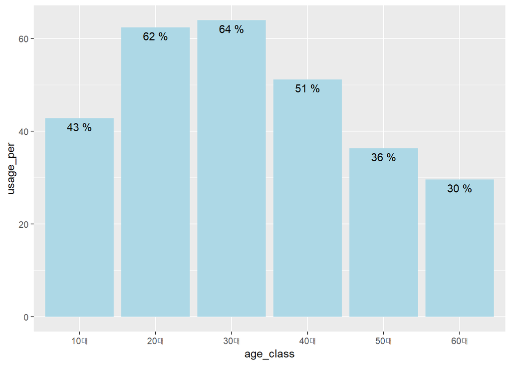

```r
# library(tidyverse)
#all<-read.csv("C:/Users/JunghaYun/Desktop/최종데이터/payments_ppdb_app_used.csv", encoding="CP949")
# View(all[1,])

all<-read.csv("C:/Users/JunghaYun/desaip/deguri_new/deguri/analysis/data/payments_ppdb_app_category_code_aggregated_x_cp949.csv", encoding = "CP949")

all<-all %>% mutate(age_class=ifelse(age<20,'10대',ifelse(age<30,'20대',ifelse(age<40,'30대',ifelse(age<50,'40대',ifelse(age<60,'50대', '60대'))))))
tot_num<-all %>% group_by(age_class) %>% count()
smartpay_num<-all %>% filter(approval_type_LT01_count!=0)  %>% group_by(age_class) %>% count()
num<-left_join(smartpay_num,tot_num,by='age_class')
num<-num %>% mutate(usage_per=n.x/n.y*100)
num %>% ggplot(aes(x=age_class,y=usage_per)) + geom_col(fill='lightblue') + geom_text(aes(label=paste(round(usage_per),"%"),vjust=1.5))
```

2. 간편결제액의 분포확인

```r
# old<-read.csv("C:/Users/JunghaYun/desaip/deguri/analysis/analysis_by_Yun/5060_3cluster.csv")
# library(tidyverse)
# light<-old %>% filter(cluster==1) %>% select(price_sum_by_by_approval_type_LT01)
# heavy<-old %>% filter(cluster==2) %>% select(price_sum_by_by_approval_type_LT01)
# light<-as.vector(as.matrix(light))
# heavy<-as.vector(as.matrix(heavy))
# usual<-old %>% filter(cluster!=2) %>% select(price_sum_by_by_approval_type_LT01)
# usual<-as.vector(as.matrix(usual))
#
# #install.packages("goft")
# library(goft)
# gamma_test(light)
# lnorm_test(light)
# gamma_test(heavy)
# lnorm_test(heavy)
# hist(light)
# hist(heavy)
#
# gamma_test(usual)
#
#
# price<-old$price_sum_by_by_approval_type_LT01[old$price_sum_by_by_approval_type_LT01>0]
# hist(price)
# bx<-boxplot(price)
# outliers<-bx$out
# usual_price<-price[!price %in% bx$out]
# length(bx$out)
# table(usual_price)
# gamma_test(usual_price)
#
#
```

3. 비교대상: k-means clustering

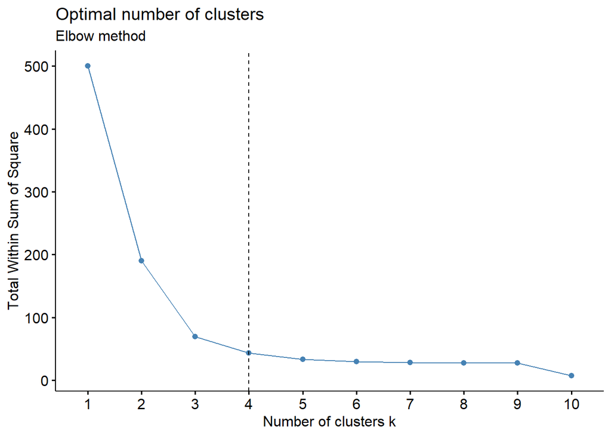

```r
#user대상 clustering
st<-scale(user$price_sum_by_by_approval_type_LT01)
easypay<-as.data.frame(st)
  #user$price_sum_by_by_approval_type_LT01)
fviz_nbclust(easypay, kmeans, method = "wss") +
    geom_vline(xintercept = 4, linetype = 2)+
  labs(subtitle = "Elbow method")
```

```r
# => 군집개수는 4개가 적합하다.
#k-means clustering (user대상)
kmeansprice<-kmeans(st, centers=4, iter.max=10000)
kmeansprice$centers
```

```
##         [,1]
## 1 -0.2823742
## 2 10.1266289
## 3  0.5920003
## 4  2.0943232
```

```r
table(kmeansprice$cluster)
```

```
##
##   1   2   3   4
## 408   3  69  21
```

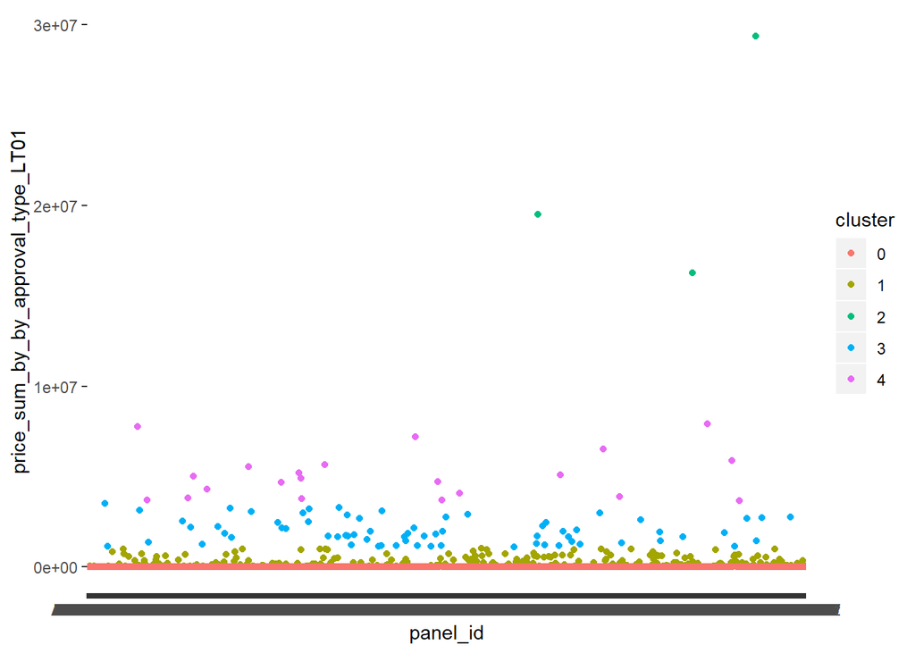

```r
user$cluster<-kmeansprice$cluster
#cluster를 factor에서 숫자로변환
user$cluster<-as.numeric(user$cluster)
# nonuser에 cluster 지정
nonuser$cluster<-0
#dataframe 조인
user.nonuser<-union(user,nonuser)
#시각화(**3개 이상치 포함)
user.nonuser$cluster<-as.factor(user.nonuser$cluster)
user.nonuser %>% ggplot(aes(x=panel_id,y=price_sum_by_by_approval_type_LT01,color=cluster))+geom_point()
```